# Energy_consumption_prediction

Upuli Karunarathna

#### **About the data set**

Based on a variety of building characteristics and environmental conditions, this data set aims to predict energy use. The description of the factors that can be influenced for energy consumption is given below.  
Building.Type : Categorical feature representing the type of building.( It is a dummy variable holds commercial type as base level)

```
            Residential Industrial
Residential           1          0
Industrial            0          1
Commercial            0          0
```

Square.Footage: Numeric feature representing the total square footage of the building.  
Number.of.Occupants: Numeric feature indicating the number of people occupying the building.  
Appliances.Used: Numeric feature representing the number of appliances used in the building.  
Average.Temperature: Numeric feature representing the average temperature of the building or climate area (in Celsius).  
Day.of.Week: Categorical feature representing whether the data point corresponds to a weekday or weekend.(Weekend = 1, Weekday = 0)  
Energy.Consumption: Numeric target variable representing the energy consumption of the building in kWh (kilowatt-hours).

#### **Checking the outliers**

1. For square footage

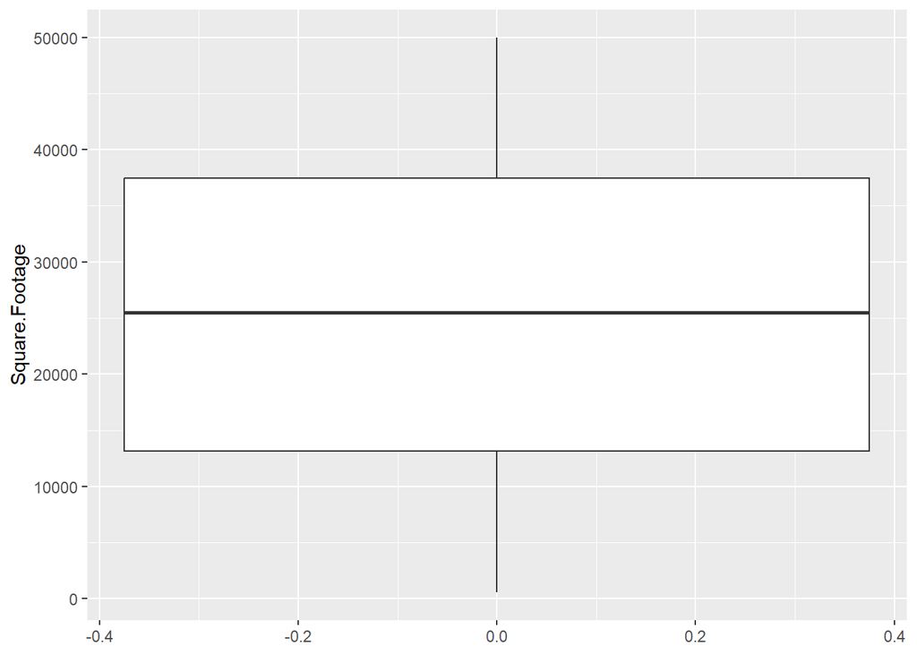

```
integer(0)
```

2. For Number of Occupants

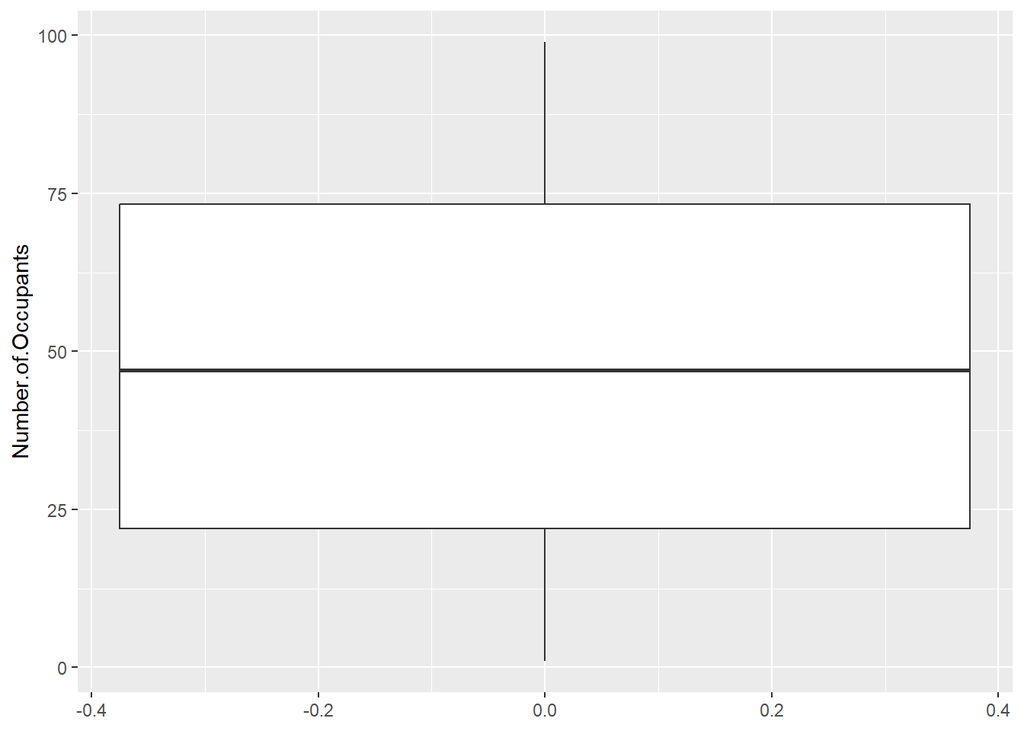

```
integer(0)
```

3. For Appliances Used

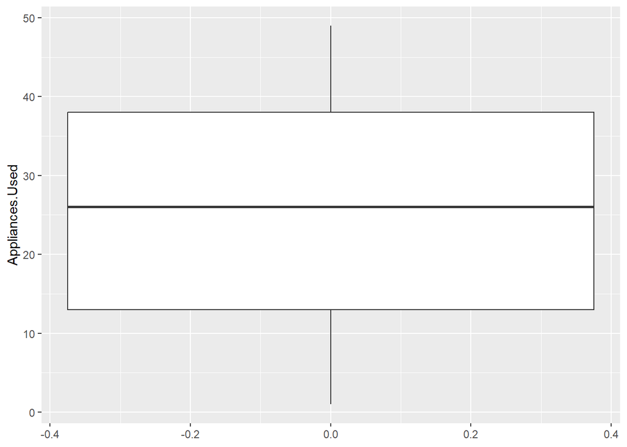

```
integer(0)
```

4. For Average Temperature

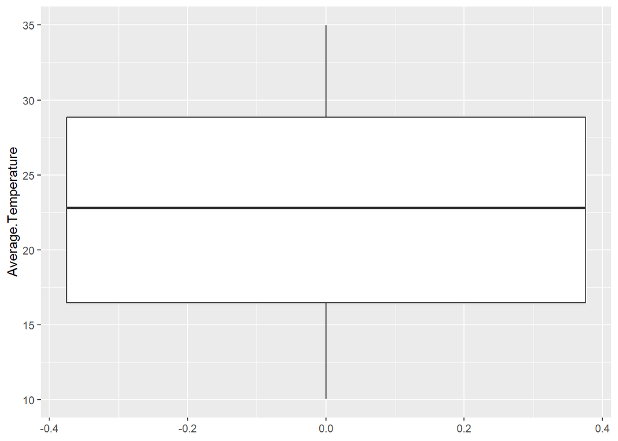

```
numeric(0)
```

5. For Energy Consumption

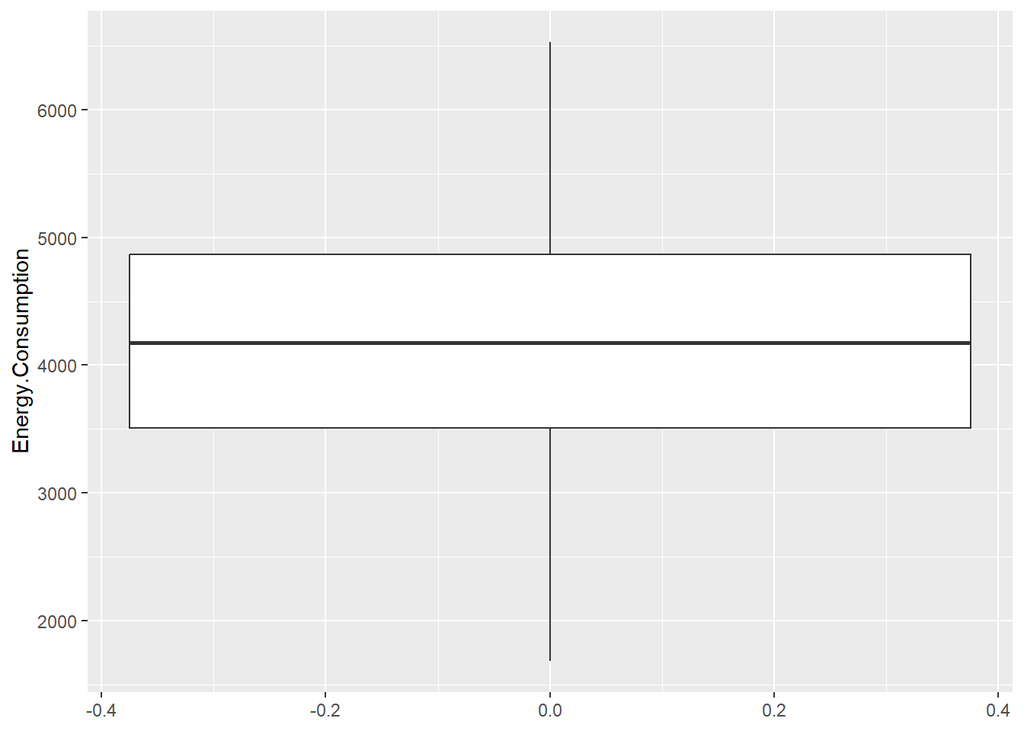

```
numeric(0)
```

All box blots and relevant counts indicate that there are no any outliers among these variables.

#### **Summary of the original data set**

```
'data.frame':   1000 obs. of  7 variables:
 $ Building.Type      : chr  "Residential" "Commercial" "Industrial" "Residential" ...
 $ Square.Footage     : int  7063 44372 19255 13265 13375 37377 38638 34950 29741 17467 ...
 $ Number.of.Occupants: int  76 66 37 14 26 26 92 60 99 42 ...
 $ Appliances.Used    : int  10 45 17 41 18 32 14 18 44 36 ...
 $ Average.Temperature: num  29.8 16.7 14.3 32.8 11.9 ...
 $ Day.of.Week        : chr  "Weekday" "Weekday" "Weekend" "Weekday" ...
 $ Energy.Consumption : num  2714 5745 4101 3009 3279 ...
```

```
 Building.Type      Square.Footage  Number.of.Occupants Appliances.Used
 Length:1000        Min.   :  560   Min.   : 1.00       Min.   : 1.00
 Class :character   1st Qu.:13170   1st Qu.:22.00       1st Qu.:13.00
 Mode  :character   Median :25477   Median :47.00       Median :26.00
                    Mean   :25462   Mean   :48.37       Mean   :25.61
                    3rd Qu.:37446   3rd Qu.:73.25       3rd Qu.:38.00
                    Max.   :49997   Max.   :99.00       Max.   :49.00
 Average.Temperature Day.of.Week        Energy.Consumption
 Min.   :10.05       Length:1000        Min.   :1684
 1st Qu.:16.48       Class :character   1st Qu.:3509
 Median :22.82       Mode  :character   Median :4176
 Mean   :22.61                          Mean   :4166
 3rd Qu.:28.85                          3rd Qu.:4864
 Max.   :34.99                          Max.   :6531
```

#### **Number of rows with null values**

```
[1] 0
```

There are no any missing values in this data set and it is a complete data set.

#### **Running a regression model to predict energy consumption**

- **Considering main effects only**

**Model specification with forward selection method**

```
                                     Stepwise Summary
----------------------------------------------------------------------------------------
Step    Variable                  AIC          SBC         SBIC         R2       Adj. R2
----------------------------------------------------------------------------------------
 0      Base Model             16518.358    16528.173    13676.481    0.00000    0.00000
 1      Square.Footage         15602.998    15617.721    12759.121    0.60043    0.60003
 2      Building.Type          14893.195    14917.734    12045.318    0.80430    0.80371
 3      Number.of.Occupants    14172.201    14201.647    11322.324    0.90503    0.90464
 4      Appliances.Used        10384.876    10419.230     7532.998    0.99785    0.99784
 5      Average.Temperature     9290.024     9329.286     6436.147    0.99928    0.99928
 6      Day.of.Week            -5732.213    -5688.043    -8571.977    1.00000    1.00000
----------------------------------------------------------------------------------------

Final Model Output
------------------

                          Model Summary
-----------------------------------------------------------------
R                       1.000       RMSE                   0.014
R-Squared               1.000       MSE                    0.000
Adj. R-Squared          1.000       Coef. Var              0.000
Pred R-Squared          1.000       AIC                -5732.213
MAE                     0.012       SBC                -5688.043
-----------------------------------------------------------------
 RMSE: Root Mean Square Error
 MSE: Mean Square Error
 MAE: Mean Absolute Error
 AIC: Akaike Information Criteria
 SBC: Schwarz Bayesian Criteria

                                        ANOVA
--------------------------------------------------------------------------------------
                     Sum of
                    Squares         DF      Mean Square           F              Sig.
--------------------------------------------------------------------------------------
Regression    870202202.846          7    124314600.407    661902125776.658    0.0000
Residual              0.186        992            0.000
Total         870202203.033        999
--------------------------------------------------------------------------------------

                                              Parameter Estimates
----------------------------------------------------------------------------------------------------------------
                   model        Beta    Std. Error    Std. Beta         t          Sig        lower       upper
----------------------------------------------------------------------------------------------------------------
             (Intercept)    2050.001         0.002                  989417.941    0.000    2049.997    2050.005
          Square.Footage       0.050         0.000        0.766    1644316.782    0.000       0.050       0.050
 Building.TypeIndustrial     500.000         0.001        0.249     465009.522    0.000     499.998     500.003
Building.TypeResidential    -500.000         0.001       -0.255    -475665.336    0.000    -500.002    -499.998
     Number.of.Occupants      10.000         0.000        0.311     669305.989    0.000      10.000      10.000
         Appliances.Used      20.000         0.000        0.302     648818.386    0.000      20.000      20.000
     Average.Temperature      -5.000         0.000       -0.038     -82067.244    0.000      -5.000      -5.000
      Day.of.WeekWeekend     -50.001         0.001       -0.027     -57640.434    0.000     -50.002     -49.999
----------------------------------------------------------------------------------------------------------------
```

According to the forward selection method, it has been decided the variables which are included in the regression model are Square.Footage, Building.TypeIndustrial, Building.TypeResidential, Number.of.Occupants, Appliances.Used, Average.Temperature and Day.of.WeekWeekend. Then the estimated regreesion model is,

$$\hat{Energy\_Consumption} = 2050.001 + 0.050 \times Square\_Footage +
500 \times Building\_Type\_(Industrial) -500 \times
TBuilding\_Type\_(Residential) + 10 \times Number\_of\_Occupants + 20
\times Appliances\_used - 5 \times Average\_Temperature - 50 \times
Day\_of\_Week\_(Weekend)$$

- **Considering interaction effects**

```
Call:
lm(formula = Energy.Consumption ~ (Square.Footage + Number.of.Occupants +
    Average.Temperature + Appliances.Used + Building.Type + Day.of.Week)^2,
    data = energy)

Residuals:
      Min        1Q    Median        3Q       Max
-0.024984 -0.010788  0.000154  0.010510  0.024920

Coefficients:
                                               Estimate Std. Error    t value
(Intercept)                                   2.050e+03  6.245e-03  3.283e+05
Square.Footage                                5.000e-02  1.406e-07  3.557e+05
Number.of.Occupants                           1.000e+01  7.024e-05  1.424e+05
Average.Temperature                          -5.000e+00  2.249e-04 -2.223e+04
Appliances.Used                               2.000e+01  1.379e-04  1.451e+05
Building.TypeIndustrial                       5.000e+02  4.968e-03  1.007e+05
Building.TypeResidential                     -5.000e+02  4.875e-03 -1.026e+05
Day.of.WeekWeekend                           -5.001e+01  4.107e-03 -1.218e+04
Square.Footage:Number.of.Occupants           -1.518e-09  1.070e-09 -1.419e+00
Square.Footage:Average.Temperature            5.205e-09  4.368e-09  1.192e+00
Square.Footage:Appliances.Used                2.575e-10  2.183e-09  1.180e-01
Square.Footage:Building.TypeIndustrial        1.145e-08  7.722e-08  1.480e-01
Square.Footage:Building.TypeResidential       7.266e-08  7.456e-08  9.740e-01
Square.Footage:Day.of.WeekWeekend             6.766e-08  6.211e-08  1.089e+00
Number.of.Occupants:Average.Temperature       1.061e-06  2.115e-06  5.020e-01
Number.of.Occupants:Appliances.Used           5.830e-07  1.081e-06  5.400e-01
Number.of.Occupants:Building.TypeIndustrial   4.696e-06  3.735e-05  1.260e-01
Number.of.Occupants:Building.TypeResidential  1.552e-06  3.658e-05  4.200e-02
Number.of.Occupants:Day.of.WeekWeekend        2.662e-05  3.007e-05  8.850e-01
Average.Temperature:Appliances.Used          -7.147e-06  4.320e-06 -1.654e+00
Average.Temperature:Building.TypeIndustrial   2.213e-04  1.523e-04  1.453e+00
Average.Temperature:Building.TypeResidential -3.243e-05  1.507e-04 -2.150e-01
Average.Temperature:Day.of.WeekWeekend        9.592e-06  1.236e-04  7.800e-02
Appliances.Used:Building.TypeIndustrial       5.703e-05  7.864e-05  7.250e-01
Appliances.Used:Building.TypeResidential      4.077e-05  7.422e-05  5.490e-01
Appliances.Used:Day.of.WeekWeekend            1.185e-04  6.258e-05  1.894e+00
Building.TypeIndustrial:Day.of.WeekWeekend   -1.094e-03  2.169e-03 -5.040e-01
Building.TypeResidential:Day.of.WeekWeekend   1.079e-04  2.117e-03  5.100e-02
                                             Pr(>|t|)
```

[output cut: 19 more lines]

```
Average.Temperature:Appliances.Used            0.0984 .
Average.Temperature:Building.TypeIndustrial    0.1465
Average.Temperature:Building.TypeResidential   0.8297
Average.Temperature:Day.of.WeekWeekend         0.9382
Appliances.Used:Building.TypeIndustrial        0.4685
Appliances.Used:Building.TypeResidential       0.5829
Appliances.Used:Day.of.WeekWeekend             0.0585 .
Building.TypeIndustrial:Day.of.WeekWeekend     0.6143
Building.TypeResidential:Day.of.WeekWeekend    0.9593
---
Signif. codes:  0 '***' 0.001 '**' 0.01 '*' 0.05 '.' 0.1 ' ' 1

Residual standard error: 0.01372 on 972 degrees of freedom
Multiple R-squared:      1, Adjusted R-squared:      1
F-statistic: 1.713e+11 on 27 and 972 DF,  p-value: < 2.2e-16
```

Hypothesis to be tested:  
H0: Coefficient of predictor variable (including intercept) are equal to zero.  
H1: Coefficient of predictor variable (including intercept) are not equal to zero.

$$\hat{Energy\_Consumption} = 2050.001 + 0.050 \times Square\_Footage +
500 \times Building\_Type\_(Industrial) -500 \times
TBuilding\_Type\_(Residential) + 10 \times Number\_of\_Occupants + 20
\times Appliances\_used - 5 \times Average\_Temperature - 50 \times
Day\_of\_Week\_(Weekend)$$

#### **Coefficients interpretation**

1. Square footage  
   On average, for each one additional square foot, energy consumption increases by 0.05 units, holding all other variables constant.
2. Number of Occupants  
   On average, for each one additional occupant, energy consumption increases by 10 kWh, assuming all other variables remain constant.
3. Average Temperature  
   On average, for each 1°C increase in temperature, energy consumption decreases by 5 kWh, assuming other factors are constant.
4. Appliances Used  
   On average, for each one additional appliance, energy consumption increases by 20 kWh, holding other factors constant.
5. Building Type(Industrial)  
   On average, industrial buildings consume energy 500 kWh more than commercial buildings (base level), holding all factors constant.
6. Building Type(Residential)  
   On average, residential buildings consume energy 500 kWh less than commercial buildings (base level), holding all factors constant.
7. Day of Week(Weekend)  
   On average, during weekends, energy consumption is 50 kWh lower than on weekdays, holding all other factors constant.

#### **Model assumptions and accuracy**

- **Checking influential points**

```
[1] Building.Type       Square.Footage      Number.of.Occupants
[4] Appliances.Used     Average.Temperature Day.of.Week
[7] Energy.Consumption
<0 rows> (or 0-length row.names)
```

There are no influential points among data.

- **Considering AIC value, Adjusted R² value, Residual standard error**

```
[1] -5732.213
```

```
[1] 1
```

```
[1] 0.01370453
```

- **Normality**

```
    Shapiro-Wilk normality test

data:  model_fitresid$.resid
W = 0.91954, p-value < 2.2e-16
```

Hypothesis to be tested:  
H0: Residuals are normally distributed vs. H1: Residuals are not normally distributed

H0 is rejected if p value < 0.05 at 5% level of significance.Since p value is less than 2.2e-16 and it is also less than 0.05. So we have enough evidence to reject H0 at 5% level of significance. Hence residuals are not normally distributed. But it is not that much essential when conducting a model for prediction purpose.

- **Gauss Markov assumptions**
1. Linearity

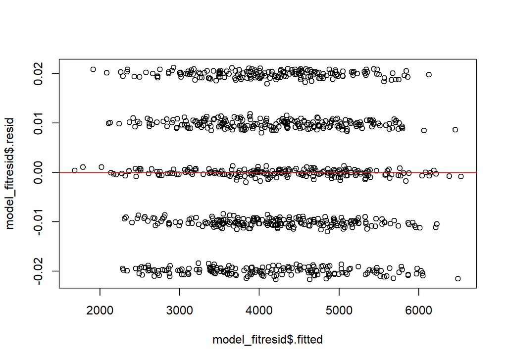

Data points are scattered around zero and there is no any specific pattern like funnel, curvature, double bow etc. But the data points are scattered like horizontal lines. It is happened because of residuals are discrete or quantized rather than continuous. It does not matter for linearity. Hence this plot shows model must be linear in parameters.

2. Independence

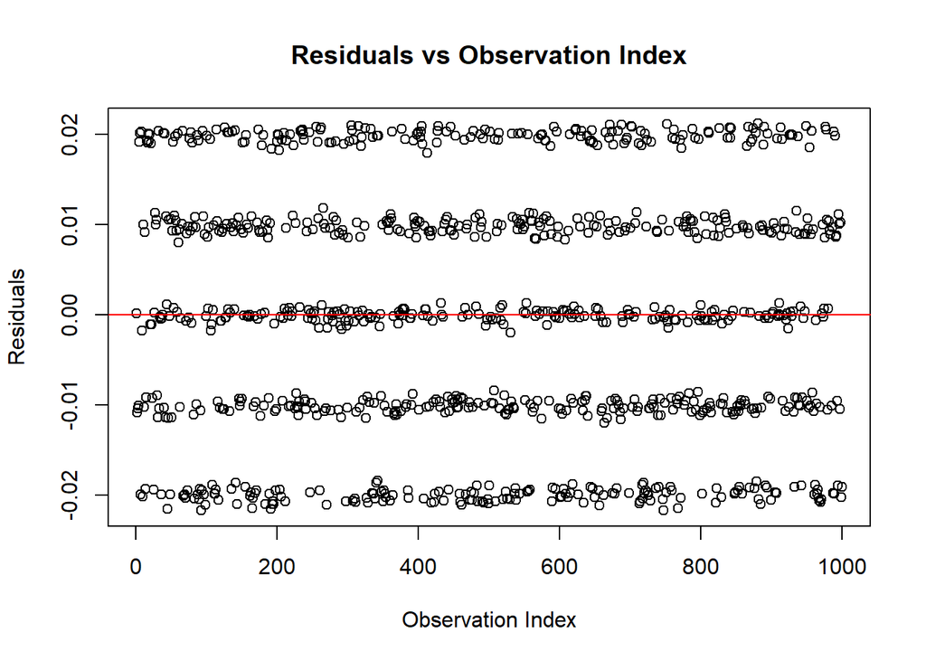

Since Residuals are scattered randomly around 0, without any specific trend or pattern.There is no obvious clustering or systematic sequence across the observation index. Hence it can be concluded that residuals are approximately independent.

3. Homoscedasticity (Constant Variance)

```
    studentized Breusch-Pagan test

data:  model
BP = 8.7024, df = 7, p-value = 0.2747
```

Hypothesis to be tested:  
H0: Residuals have constant variance vs. H1: Residuals have not constant variance

H0 is rejected if p value < 0.05 at 5% level of significance.Since p value = 0.2747 > 0.05, we do not have enough evidence to reject H0 at 5% level of significance. Hence homoscedasticity assumption is not violated.

4. No Perfect Multicollinearity

```
                        GVIF Df GVIF^(1/(2*Df))
Square.Footage      1.004956  1        1.002475
Number.of.Occupants 1.002855  1        1.001426
Average.Temperature 1.006549  1        1.003269
Appliances.Used     1.005560  1        1.002776
Building.Type       1.006974  2        1.001739
Day.of.Week         1.001441  1        1.000720
```

Since the VIF values for the variables are close to 1 it can be concluded that there is no correlation among variables and then the there is no perfect multicollinearity.

5. Zero conditional mean

```
[1] -5.168204e-13
```

Since the mean of residuals are very close to zero, it can be said that the residuals have zero conditional mean.

#### **Conclusions**

1. Increment of square footage, number of occupants, appliances used may affect to increase the energy consumption.
2. Increments of average temperature may affect to reduce the energy consumption.  
   3.Residential type of Buildings can influenced to reduce energy consumption rather than industrial type of buildings compared to commercial type of buildings.